# R Notebook

# Analysis

## Hypothesis on Why the Women’s Models Fit Better

Offensive and defensive efficiency measure how many points a team scores or allows over the course of 100 possessions. Net team efficiency, then, is the difference between the two - positive if you score more, negative if you allow more. Looking at the distribution of net team ratings will tell us how spread out the data is.

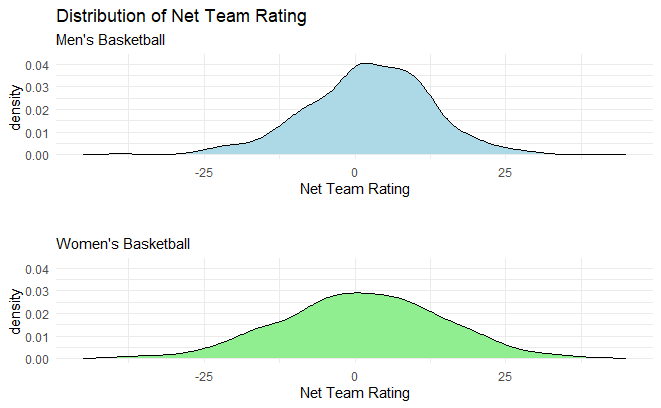

```r
mens_net_dist<- ggplot(data = mens_stats, aes(x = TmNetRtg)) +
  geom_density(fill = 'lightblue') +
  ylim(0, .042) +
  xlim(-45, 45) +
  theme_minimal() +
  labs(title = "Distribution of Net Team Rating",
       subtitle = "Men's Basketball",
       x = "Net Team Rating")

womens_net_dist<- ggplot(data = womens_stats, aes(x = TmNetRtg)) +
  geom_density(fill = 'lightgreen') +
  ylim(0, .042) +
  xlim(-45, 45) +
  theme_minimal() +
  labs(title = "",
       subtitle = "Women's Basketball",
       x = "Net Team Rating")

grid.arrange(mens_net_dist, womens_net_dist)
```

What we find is that there is far more variance in the women’s data than there is in the men’s data. Men’s teams are much more centered around 0 when compared to the women’s data, which has huge tails on either side. In fact, net team rating among men’s teams has a standard deviation of 10.09, while the standard deviation among women’s teams is 13.37.

You might be saying to yourself, “but wait, net team efficiency isn’t a variable in our models. What does this have to do with anything?” What this tells me is that overall, men’s teams are much more similar to each other than women’s teams are. Therefore, on a game to game basis, we would be much more likely to see an “upset” in men’s basketball than in women’s basketball, which affects the target variable of our models.

Further, if the men’s teams are more similar to each other than women’s teams are, it makes it more difficult to sort out who would have a higher winning percentage and make predictions.

Again, this is simply a hypothesis, and there are dozens of factors that can affect why the women’s data fit our model better. However, I believe this is a good place to start for explaining the differences.

## Predictions of Postseason Success

The ultimate goal of a model like this would be to try and predict which teams will make it the farthest in the March Madness tournament at the end of the season. March Madness, at least on the men’s side, often gets a reputation of being a tournament where anyone can beat anyone. On a single-game basis that may be true, but 92% of all NCAA men’s basketball champions were seeded 1-4. So, over the course of a full tournament, we would expect the best teams (teams that are most effective in the Four Factors) to rise to the top.

The women’s game is even more stratified if we look at teams that advance to the Final Four. Only four times in history has a team seeded higher than 5 advanced to the Final Four, and no team seeded higher than 3 has ever won the national championship. To that end, I would expect these models to predict post-season success fairly accurately.

Seeing as the two Lasso regressions had the highest R-Squared values, let’s look at how they predict postseason success.

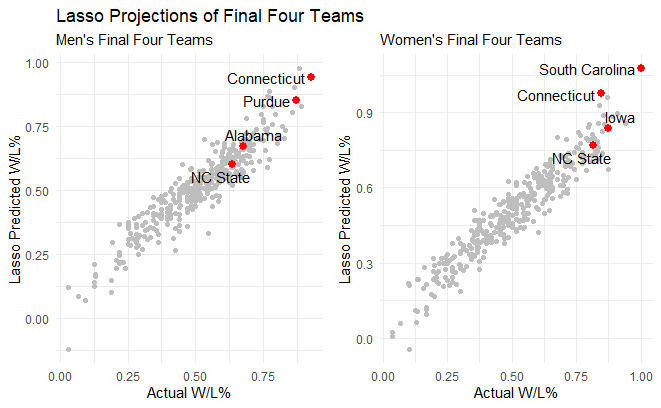

```r
library(ggrepel)

mens_final_four_teams<- mens_lasso_comp |>
  filter(team %in% c("Connecticut", "Alabama", "Purdue", "NC State"))

womens_final_four_teams<- womens_lasso_comp |>
  filter(team %in% c("South Carolina", "Iowa", "NC State", "Connecticut"))

mens_final_four_hl<- ggplot() +
  geom_point(data = mens_lasso_comp, aes(x = actual, y = predicted), color = "grey") + geom_point(data = mens_final_four_teams, aes(x = actual, y = predicted), color = "red", size = 2.5) +
  geom_text_repel(data = mens_final_four_teams, aes(x = actual, y = predicted, label = team)) +
  theme_minimal()+
  labs(title = "Lasso Projections of Final Four Teams",
       subtitle = "Men's Final Four Teams",
       x = "Actual W/L%",
       y = "Lasso Predicted W/L%")

womens_final_four_hl<- ggplot() +
  geom_point(data = womens_lasso_comp, aes(x = actual, y = predicted), color = "grey") + geom_point(data = womens_final_four_teams, aes(x = actual, y = predicted), color = "red", size = 2.5) +
  geom_text_repel(data = womens_final_four_teams, aes(x = actual, y = predicted, label = team)) +
  theme_minimal() +
  labs(title = "",
       subtitle = "Women's Final Four Teams",
       x = "Actual W/L%",
       y = "Lasso Predicted W/L%")
grid.arrange(mens_final_four_hl, womens_final_four_hl, nrow = 1, ncol = 2)
```

```r
NA
```

# Conclusions

## On The Models

I think that this model turned out to be a pretty good starting point for trying to predict the overall success of a basketball team. For the original goal of recreating SP+ for basketball using Dean Oliver’s Four Factors, we got solid results measuring >87% of the variance in team performance for both men’s and women’s basketball.

There is almost certainly a way to make a model that improves these R-Squared values to even more accurately predict team success. Further research would, of course, need to be done. I think an interesting factor to add would be specifically trying to predict post-season success. Adding binary variables for which round of March Madness each team advanced to could give us interesting insight into what makes a team “championship caliber”. Whereas in this model we were solely looking at winning percentage and not post season success, that sort of model could help fans know which teams to keep their eyes on come March Madness.

## Personal Reflections

I was a little disappointed while working on this project that the models I wrote myself did not turn out to be as accurate as I would have liked. I had hoped that optimizing the weights and writing out the objective functions would give better results, mostly from a pride aspect. Data science is not always that clean.

I am grateful, however, for the vast libraries available from which to pull in machine learning models. The Caret package gave great results with which I am pleased.

Overall, it was a great learning experience to go through the full process of building a model. From starting out with a goal in mind, finding road blocks along the way, and utilizing resources to overcome those obstacles, I learned quite a bit about the data science process along the way and I am certain that these experiences will help me in future endeavors. In fact, I already have a couple of ideas for the next topics I would like to research.

Connelly, Bill. 2017. “Explaining s&p+, College Football’s Deepest Advanced Analytics System.” https://www.sbnation.com/college-football/2017/10/13/16457830/college-football-advanced-stats-analytics-rankings.

Fernandez, George CJ. 1992. “Residual Analysis and Data Transformations: Important Tools in Statistical Analysis.” *HortScience* 27 (4): 297–300.

Fonti, Valeria, and Eduard Belitser. 2017. “Feature Selection Using Lasso.” *VU Amsterdam Research Paper in Business Analytics* 30: 1–25.

Lehmann, E. L. 2011. “On the History and Use of Some Standard Statistical Models.” *Selected Works of E. L. Lehmann*, November, 1019–31. https://doi.org/10.1007/978-1-4614-1412-4_85.

Oliver, Dean. 2011. *Basketball on Paper: Rules and Tools for Performance Analysis*. Potomac Books, Inc.

Pomeroy, Ken. 2004. “The Possession.” *Kenpom.com*. https://kenpom.com/blog/the-possession/.

Sports Reference, LLC. 2024. “College Basketball School Stats.” https://www.basketball-reference.com/10-21-2024.